# Analiza ekploracyjna filmów Tarantino

Magdalena Koczy, Martyna Stalmach

2022-06-06

# Wprowadzenie

Celem projektu jest eksploracja danych o filmach reżyserowanych przez Quentina Tarantino. Dane na ten temat zostały zebrane przez dziennikarza FiveThirtyEight.

# Obróbka danych

Dane wczytano bezpośrednio z pakietu Rstudio. Dodano kolumny bled_out_or_cursed, year oraz duration zawierające następujące dane:

- informacje czy w danej minucie nastąpiło wykrwawienie, czy też został wypowiedziany wulgaryzm
- rok premiery
- czas trwania filmu

Statystyki podsumowujące wybrane zmienne przedstawiają się następująco:

|  | movie | profane | word | minutes_in | year | duration | bled_out_or_cursed |
| --- | --- | --- | --- | --- | --- | --- | --- |
|  | Length:1894 | Mode :logical | Length:1894 | Min. : 0.40 | Length:1894 | Min. : 99 | Length:1894 |
|  | Class :character | FALSE:190 | Class :character | 1st Qu.: 29.66 | Class :character | 1st Qu.:111 | Class :character |
|  | Mode :character | TRUE :1704 | Mode :character | Median : 70.53 | Mode :character | Median :154 | Mode :character |
|  |  |  |  | Mean : 71.53 |  | Mean :141 |  |
|  |  |  |  | 3rd Qu.:112.83 |  | 3rd Qu.:160 |  |
|  |  |  |  | Max. :160.45 |  | Max. :165 |  |

Z powyższej tabeli można odczytać m.in. średni czas trwania filmów Tarantino, pierwszą i ostatnią minutę w której pada przekleństwo, bądź ktoś umiera oraz ilość wszystkich wulgaryzmów i śmierci we wszystkich filmach.

## Wykorzystane zmienne

| Zmienna | Opis |
| --- | --- |
| *movie* | film |
| *profane* | czy wulgaryzm (Fałsz, Prawda) |
| *word* | wypowiedziane słowo |
| *minutes_in* | czas w minutach |
| *bled_out_or_cursed* | wykrwawienie czy przekleństwo |
| *year* | rok premiery |
| *duration* | czas trwania filmu |

# Analizy

Przeprowadzona analiza obejmowała następujące zagadnienia:

- analizę wulgaryzmów - m.in. liczbę przekleństw w podziale na okresy czasowe, ich rodzaje, wpływ upływu czasu na ich ilość i typ.
- analizę wykrwawień - liczbę oraz zawartość procentową zgonów w podziale zarówno na okresy czasowe, jak i filmy.
- analizę porównawczą - zbadanie zaistnienia sytuacji, w której zarówno wulgaryzm, jak i śmierć nastepują w zbliżonym momencie. Porównanie ogólnej ilości wulgaryzmów i śmierci.

## Analiza wulgaryzmów

Celem tej analizy jest sprawdzenie, czy istnieje jakaś zależność między ilością przekleństw, a etapem filmu oraz jakie typy wulgaryzmów dominowały w poszczególnych filmach.

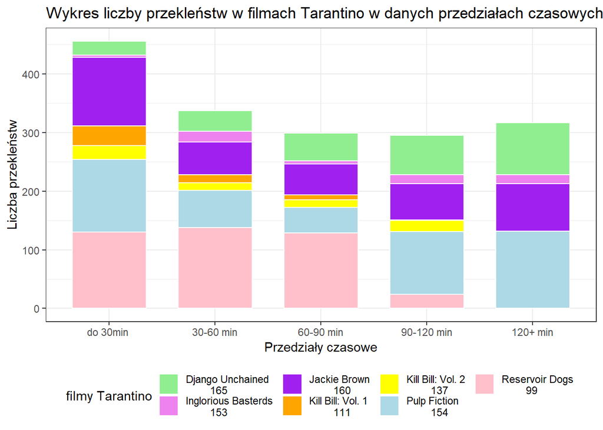

```
## # A tibble: 7 x 6
##   movie              `do 30min ` `30-60 min` `60-90 min` `90-120 min` `120+ min`
##   <chr>                    <int>       <int>       <int>        <int>      <int>
## 1 Django Unchained            24          35          47           67         89
## 2 Inglorious Baster~           4          18           6           15         15
## 3 Jackie Brown               117          56          52           62         81
## 4 Kill Bill: Vol. 1           33          14           9            1          0
## 5 Kill Bill: Vol. 2           24          13          13           19          0
## 6 Pulp Fiction               124          63          43          107        132
## 7 Reservoir Dogs             130         138         129           24          0
```

W legendzie do przedstawionych danych, do nazwy filmu dodano czas jego trwania. Według przedstawionego schematu najwięcej przekleństw pada w pierwszych 30 minutach filmów. Najmniej w tym przedziale pada przekleństw w Inglorius Basterds (Bękartach wojny). Rekordowa ilość przekleństw, w każdym przedziale czasowym, aż do końca trwania filmu, pada w Reservoir Dogs (Wściekłych psach). (Przedostatni i ostatni przedział należy pominąć, ponieważ film trwa tylko 99 minut.)

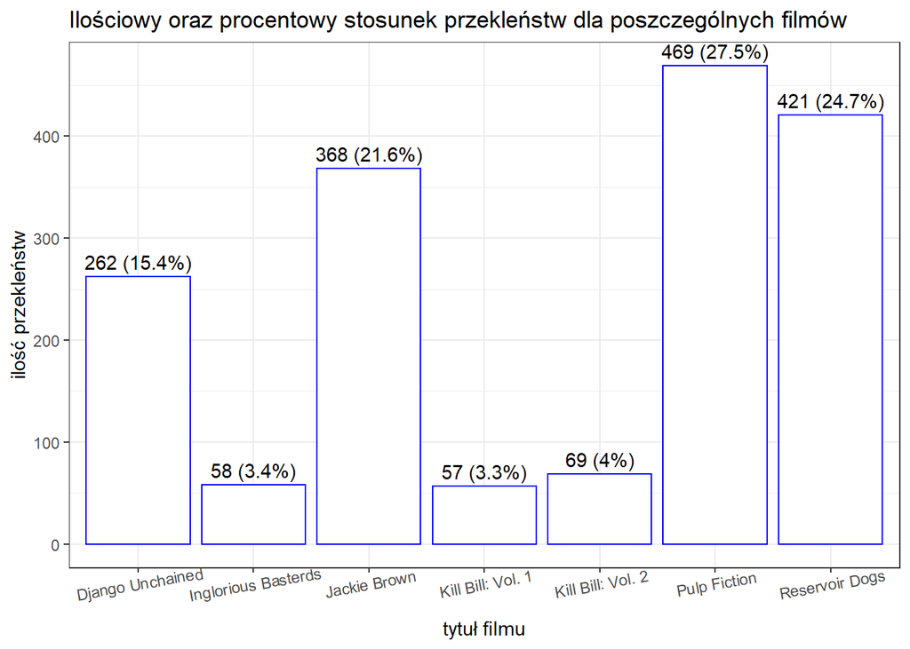

Reservoir Dogs nie jest jednak najbardziej wulgarnym filmem spośród tutaj zebranych. Pulp Fiction zawiera ponad ćwierć wszystkich zebranych przekleństw. To ponad dwukrotnie więcej, niż razem wzięte Kill Bill: Vol. 1, Kill Bill: Vol. 2 oraz Inglorious Basterds. Warto jednak zauważyć, że Kill Bill`e to specyficzne dzieła Tarantino i wśród natłoku walk nie ma w nich, aż tyle czasu na przekleństwa.

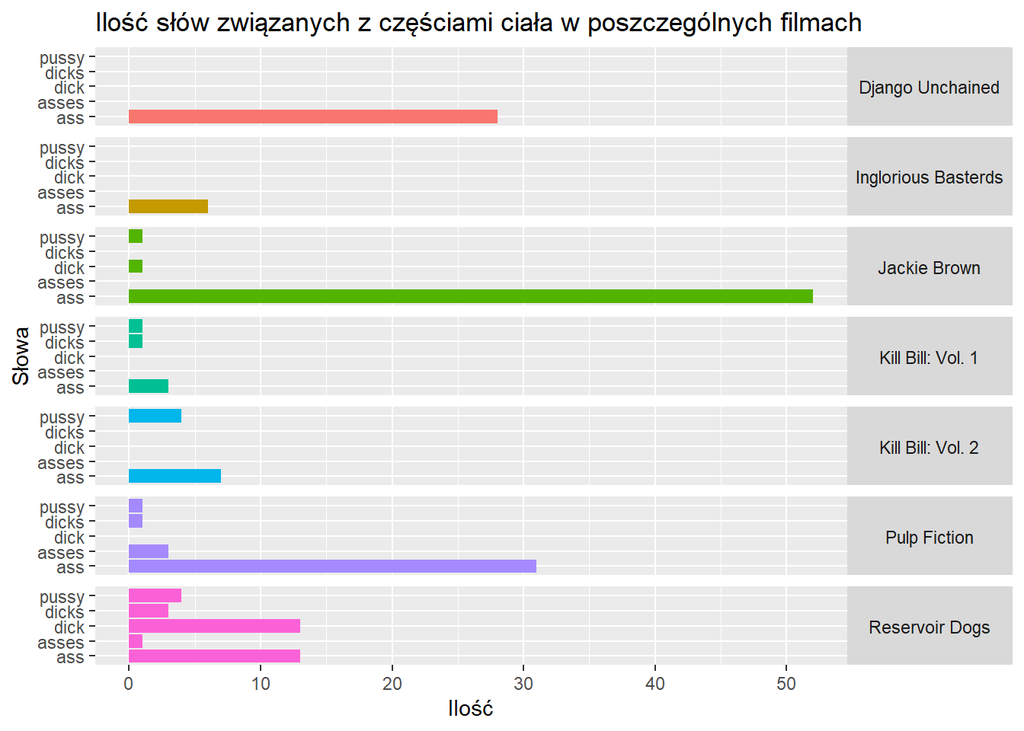

Zdecydowanie w powyższej statystyce przoduje słowo ,,ass”. Znajduje sie ono niejednokrotnie w każdym filmie, słowa związane z pośladkami są również najliczniejszą grupą spośród słów powiązanych z częściami ciała. Na wykresie można również zauważyć, że najbardziej różnorodnym w tej kategorii filmem jest Reservoir Dogs.

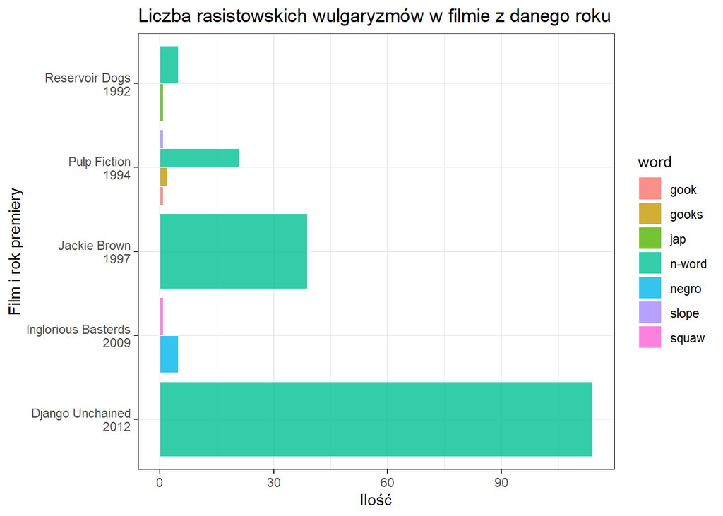

Wykres nie pozostawia wapliwości, jaki jest najchętniej używany rasistowski wulgaryzm. W Django oraz Jakie Brown nie użyto żadnego innego. Jednak w tym pierwszym zostało wypowiedziane prawie trzykrotnie razy więcej. Można zauważyć również, że gdy już n-word był używany, to tym więcej, im późniejsza jest data produkcji filmu. Największa różnorodność wśród rasistowskich wulgaryzmów znajduje się w Pulp Fiction.

## Analiza wykrwawień

W tej części sprawdzono zależność procentowa ilości wykrwawień w danym etapie (przedziale czasowym) filmu.

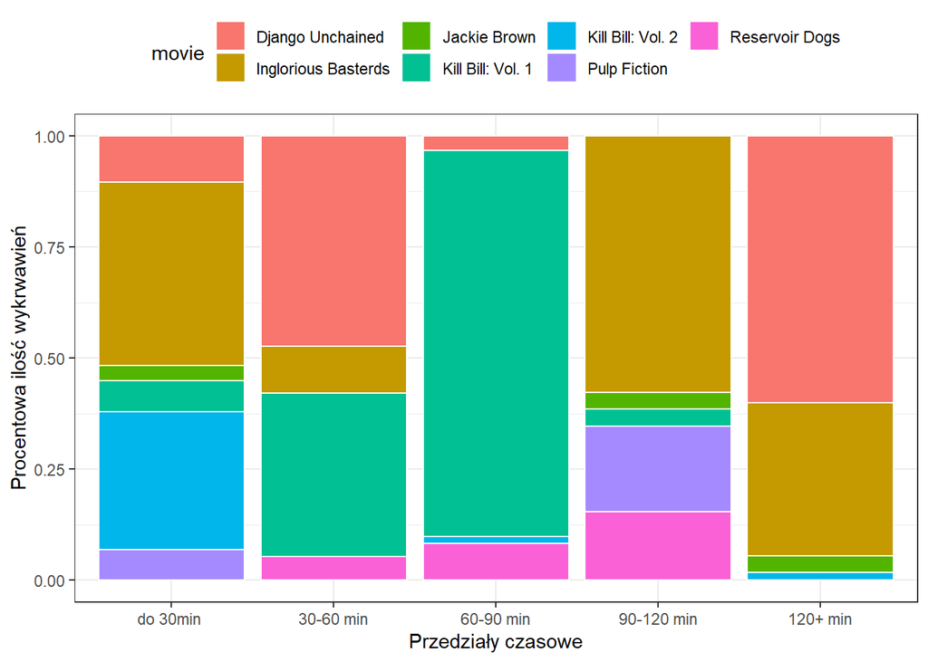

Pierwsze, co rzuca sie w oczy w powyższej wizualizacji to znaczna obecność Kill Bill`a w środkowym przedziale. Jednak należy pamiętać, że jest to wykres procentowy, co może oznaczać, że niekoniecznie występowało tam wiele śmierci, a na przykład to, że w pozostałych filmach znajdowało się ich mniej lub wcale. Ciekawe jest również to, że w tym przedziale nie ma w ogóle koloru odpowiadającemu Inglorious Basterds, który w innych przedziałach ma znaczące udziały procentowe.

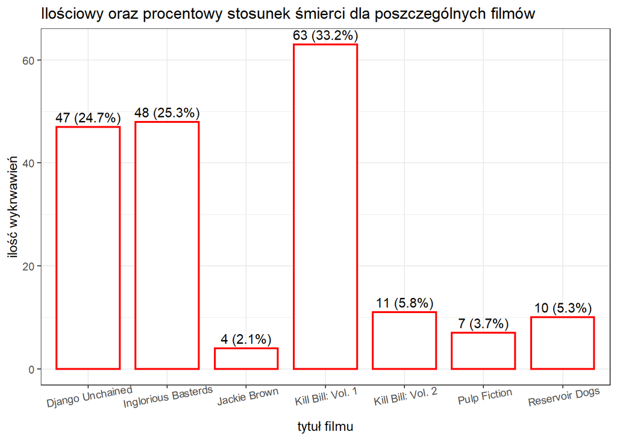

W tej analizie widzimy, że najwiecej wykrwawień znajduje się w filmie Kill Bill: Vol.1. Biorąc pod uwagę poprzedni wykres można wywnioskować, że wiekszość z nich wydarzyła się między 60, a 90 minutą.

## Analiza łącząca

W tym etapie analizy sprawdzono, czy dane o wulgaryzmach i o przekleństwach są od siebie zależne.

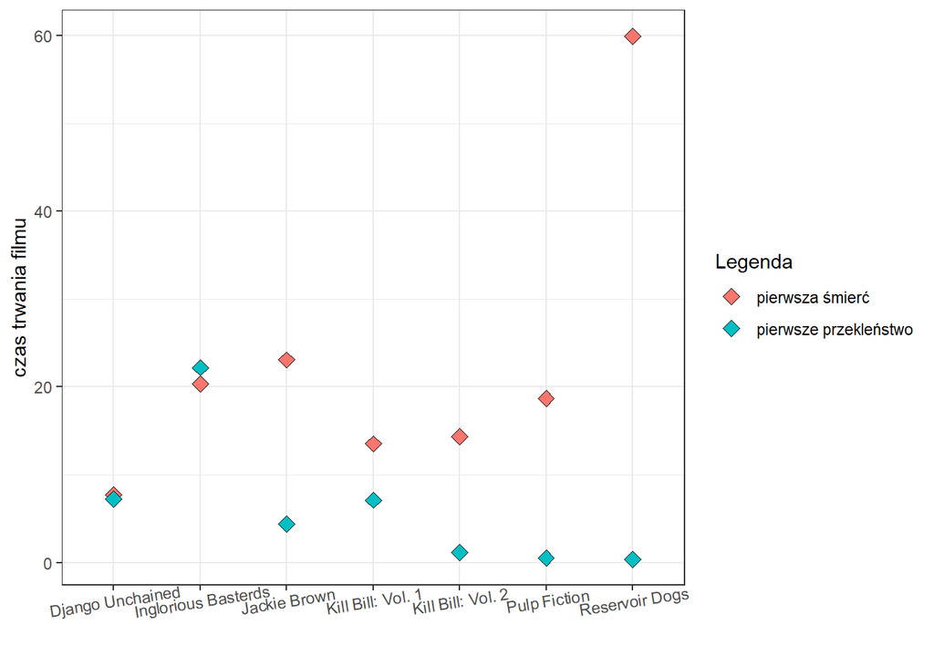

```
## # A tibble: 14 x 3
## # Groups:   movie [7]
##    movie               profane pierwsze
##    <chr>               <lgl>      <dbl>
##  1 Django Unchained    FALSE       7.75
##  2 Django Unchained    TRUE        7.23
##  3 Inglorious Basterds FALSE      20.4
##  4 Inglorious Basterds TRUE       22.2
##  5 Jackie Brown        FALSE      23.1
##  6 Jackie Brown        TRUE        4.38
##  7 Kill Bill: Vol. 1   FALSE      13.5
##  8 Kill Bill: Vol. 1   TRUE        7.12
##  9 Kill Bill: Vol. 2   FALSE      14.4
## 10 Kill Bill: Vol. 2   TRUE        1.18
## 11 Pulp Fiction        FALSE      18.7
## 12 Pulp Fiction        TRUE        0.52
## 13 Reservoir Dogs      FALSE      59.9
## 14 Reservoir Dogs      TRUE        0.4
```

Z wykresu oraz tabeli można odczytać, że wszystkie pierwsze przekleństwa padły przed upływem dwóch kwadransów. Podobnie byłoby z śmierciami, gdyby nie Reservoir Dogs. Pierwsze wykrwawienie nastepuje tam dopiero po godzinie, co ciekawe, jest to również film z najwcześniej padającym przekleństwem, które następuje już w pierwszej minucie. W filmie Django Unchained zarówno przekleństwo, jak i pierwsza śmierć mają miejsce w niemal tym samym momencie, co sugeruje gwałtowność sceny.

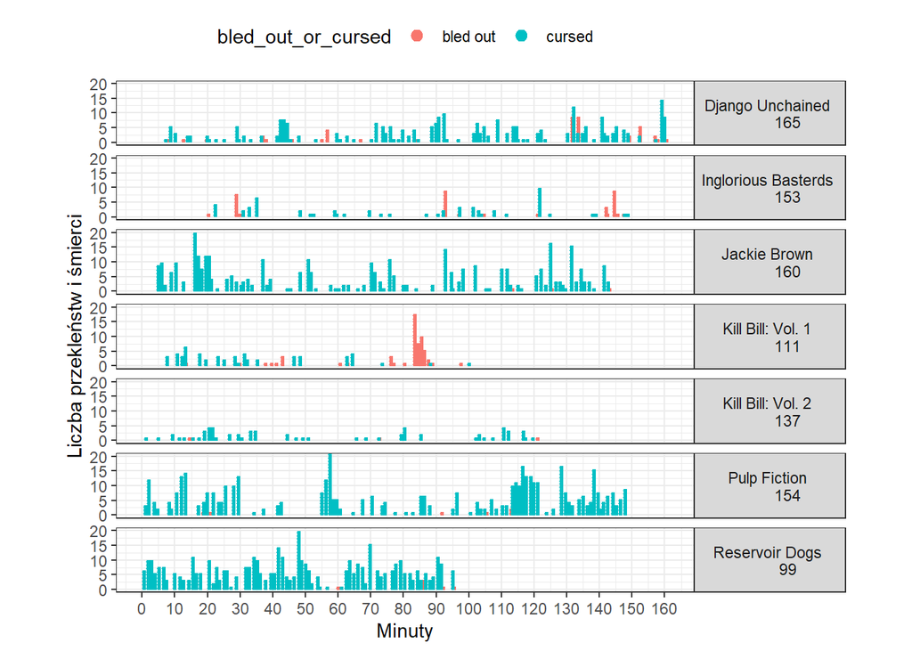

Z powyższego wykresu można odczytać, w których momentach występowały śmierci wraz z wulgaryzmami. Widać również, że zwykle sama końcówka filmu jest spokojna. Z wykresu wynika, że faktycznie, tak jak wczesniej się domyślaliśmy, w Kill Bill`u Vol. 1 odbywa się długa, krwawa scena.

```
##
##                        bled out    cursed
##   Django Unchained    24.736842 15.375587
##   Inglorious Basterds 25.263158  3.403756
##   Jackie Brown         2.105263 21.596244
##   Kill Bill: Vol. 1   33.157895  3.345070
##   Kill Bill: Vol. 2    5.789474  4.049296
##   Pulp Fiction         3.684211 27.523474
##   Reservoir Dogs       5.263158 24.706573
```

Powyższa tabela pokazuje procentowy stosunek wykrwawień oraz przekleństw. Najwięcej przekleństw procentowo jest wypowiedzianych w Pulp Fiction. Natomiast najmniej osób wykrwawia się w filmie Jacki Brown. Ciekawą obserwacją jest, że niemalże tak samo duży procent mają wykrwawienia w Django Unchained, jak przekleństwa w Reservoir Dogs.

```
## # A tibble: 7 x 4
## # Groups:   movie [7]
##   movie               year  `bled out` cursed
##   <chr>               <chr>      <dbl>  <dbl>
## 1 Reservoir Dogs      1992      0.101   4.25
## 2 Pulp Fiction        1994      0.0455  3.05
## 3 Jackie Brown        1997      0.025   2.3
## 4 Kill Bill: Vol. 1   2003      0.568   0.514
## 5 Kill Bill: Vol. 2   2004      0.0803  0.504
## 6 Inglorious Basterds 2009      0.314   0.379
## 7 Django Unchained    2012      0.285   1.59
```

Ostatnia tabela podsumowuje nam jaki był stosunek śmierci (bled_out) oraz przekleństw (cursed) do czasu (w minutach). Odczytujemy, że najbardziej krwawym filmem był Kill Bill: Vol.1, a najbardziej wulgarnym Reservoir Dogs, który jest zarówno pierwszym chronologicznie filmem Tarantino.

# Wnioski

1. Filmem Tarantino z najwyższym wskaźnikiem przekleństw na minutę jest jego pierwsze dzieło Reservoir Dogs. Jednak film, który posiada najwięcej przekleństw to Pulp Fiction, drugi film na osi czasu.
2. Film z największą ilością śmierci, jak i ich stosunku do czasu trwania to Kill Bill: Vol 1 z 2003 roku.
3. Najchętniej używanym wulgaryzmem związanym z ciałem bylo ,,ass’’, z znaczą przewagą nad resztą.
4. Wśród rasistowskich wulgaryzmów znacząco dominowało ,,n-word’’, które gdy już zostało w filmie użyte, wystepowało z biegiem czasu w coraz większych ilościach.
5. Zarówno pierwsza śmierć jak i pierwsze przekleństwo padają do 25 minuty filmu, za wyjątkiem Reservoir Dogs. Przy czym zazwyczaj nie wystepują zaraz po sobie.
6. Końcówka filmu zwykle nie zawiera ani przekleństw, ani śmierci. Po burzliwych, kulminacyjnych scenach reżyser daje widzowi odpocząć.

# Co dalej?

Dalsze analizy mogłyby uwzględnić:

- sporządzenie takiego zestawienia dla całej filmografi Tarantino,
- uzycie nie tylko wulgarnych wyrazów, ale i gestów,
- poszerzenie bazy danych o budżet poszczególnych produkcji,
- ilość wulgaryzmów na przestrzeni lat w wypowiedziach reżysera (social media/korespondencja/wywiady)